## EDA for Dwelling Type data

First start by getting the libraries that we need.

```r
library(tidyverse)
library(Hmisc)
library(corrplot)
```

The second step is to make sure the code runs in the right path. This is ensured by setting the working directory to the location of this markdown file. As per, https://github.com/rstudio/rstudio/issues/1738, this is expected so removing from the markdown code but will keep in R files.

```r
#getwd()
#setwd(dirname(rstudioapi::getActiveDocumentContext()$path))
```

Now that the working directory has been set the data can be retrieved from the csv files. Both dwelling type and the NSW mesh block csv’s are retrieved; mesh blocks are for filtering and for providing context about where in NSW the SA2 code is.

Once the mesh block data has been loaded it is rolled up to a SA2 level; check for duplicates.

```r
# read cleaned data set
dwelling_type <- read_csv("../Data Files/ABS/Dwelling_Type_SA2.csv")
mesh_blocks <- read_csv("../../Raw Data/Data Files/ABS/Mesh_Blocks/MB_2016_NSW.csv")
#str(mesh_blocks)

# Get mesh block data at SA2 level
sa2_data <- mesh_blocks %>%
  distinct(SA2_MAINCODE_2016, SA2_NAME_2016, STATE_CODE_2016, STATE_NAME_2016)

# No duplicate SA2 Codes
sa2_data %>%
  group_by(SA2_MAINCODE_2016) %>%
  summarise(cnt = n()) %>%
  filter(cnt > 1)
```

```
## # A tibble: 0 x 2
## # ... with 2 variables: SA2_MAINCODE_2016 <int>, cnt <int>
```

## Data Checks

The first check is run against the total number of dwellings in a SA2. The returned histogram seems to indicate there are SA2’s with zero dwellings.

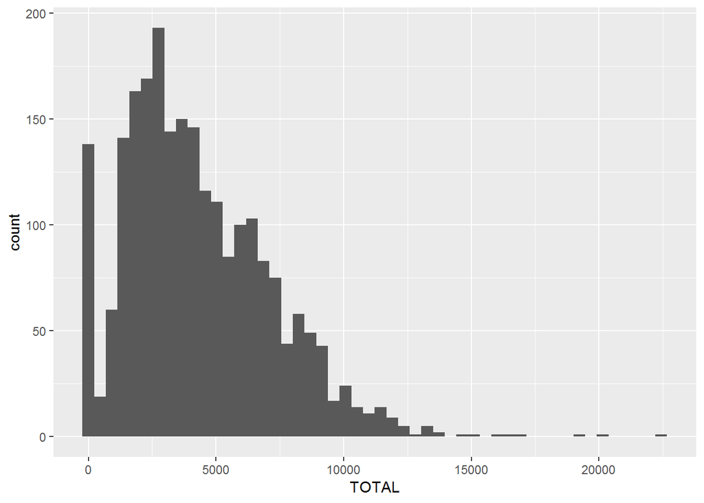

```r
# Some SA2's don't have any dwellings - positive skew
dwelling_type %>%
  mutate(TOTAL= DWELLING_HOUSE + DWELLING_FLAT + DWELLING_SEMI + DWELLING_OTHER) %>%
  ggplot() +
  geom_histogram(aes(x = TOTAL), bins = 50)
```

By looking closely at the SA2’s in NSW with no dwellings it is obviously this data is reasonably correct as they include a military base, a park and a cemetry.

```r
# 62 SA2's have no dwellings - 7 in NSW, a military base, centennial park, a NP, a cemetry, and Industrial area, Banksmeadow is whaves and industry
dwelling_type %>%
  mutate(TOTAL= DWELLING_HOUSE + DWELLING_FLAT + DWELLING_SEMI + DWELLING_OTHER) %>%
  filter(TOTAL == 0) %>%
  left_join(sa2_data, by = c("SA2_CODE" = "SA2_MAINCODE_2016")) %>%
  select(SA2_CODE, TOTAL, SA2_NAME_2016, STATE_NAME_2016) %>%
  filter(between(SA2_CODE,100000000,200000000))
```

```
## # A tibble: 7 x 4
##    SA2_CODE TOTAL SA2_NAME_2016               STATE_NAME_2016
##       <int> <dbl> <chr>                       <chr>
## 1 103031075     0 Wollangambe - Wollemi       New South Wales
## 2 107021135     0 Illawarra Catchment Reserve New South Wales
## 3 117011320     0 Banksmeadow                 New South Wales
## 4 118011342     0 Centennial Park             New South Wales
## 5 123021439     0 Holsworthy Military Area    New South Wales
## 6 125011475     0 Rookwood Cemetery           New South Wales
## 7 125031487     0 Yennora Industrial          New South Wales
```

There are also a number of SA2’s with a high number of dwellings. Are these outliers correct? The one SA2 with over 15000 dwellings is located in Waterloo/Beaconsfield in Sydney. This area is highly populated so 15,000 dwellings may not be wrong .

```r
# There are a couple of areas with high numbers of dwellings - Waterloo/Beaconsfield in NSW is high density
dwelling_type %>%
  mutate(TOTAL= DWELLING_HOUSE + DWELLING_FLAT + DWELLING_SEMI + DWELLING_OTHER) %>%
  filter(TOTAL > 15000) %>%
  left_join(sa2_data, by = c("SA2_CODE" = "SA2_MAINCODE_2016")) %>%
  select(SA2_CODE, TOTAL, SA2_NAME_2016, STATE_NAME_2016) %>%
  filter(between(SA2_CODE,100000000,200000000))
```

```
## # A tibble: 1 x 4
##    SA2_CODE TOTAL SA2_NAME_2016           STATE_NAME_2016
##       <int> <dbl> <chr>                   <chr>
## 1 117031338 17004 Waterloo - Beaconsfield New South Wales
```

For the rest of this analysis the SA2’s with no dwellings will be removed but the Waterloo/Beaconsfield SA2 will be kept in as the result appears to be valid. The inner join to the sa2_data will filter out all non-NSW SA2’s.

```r
# Remove SA2's with no dwellings and only show NSW SA2's
dwelling_type_filtered <- dwelling_type %>%
  mutate(TOTAL= DWELLING_HOUSE + DWELLING_FLAT + DWELLING_SEMI + DWELLING_OTHER) %>%
  filter(TOTAL != 0) %>%
  inner_join(sa2_data, by = c("SA2_CODE" = "SA2_MAINCODE_2016"))
```

### Normal Distribution check

With the filtered dataset check for normality. For GLM’s I don’t think normality is absolutely required unless we start calculating p values. Normally distributed data is required for correctly calculating p values.

Start by plotting a histogram for each of the dwelling bands and check shape of plot.

#### Dwelling - House

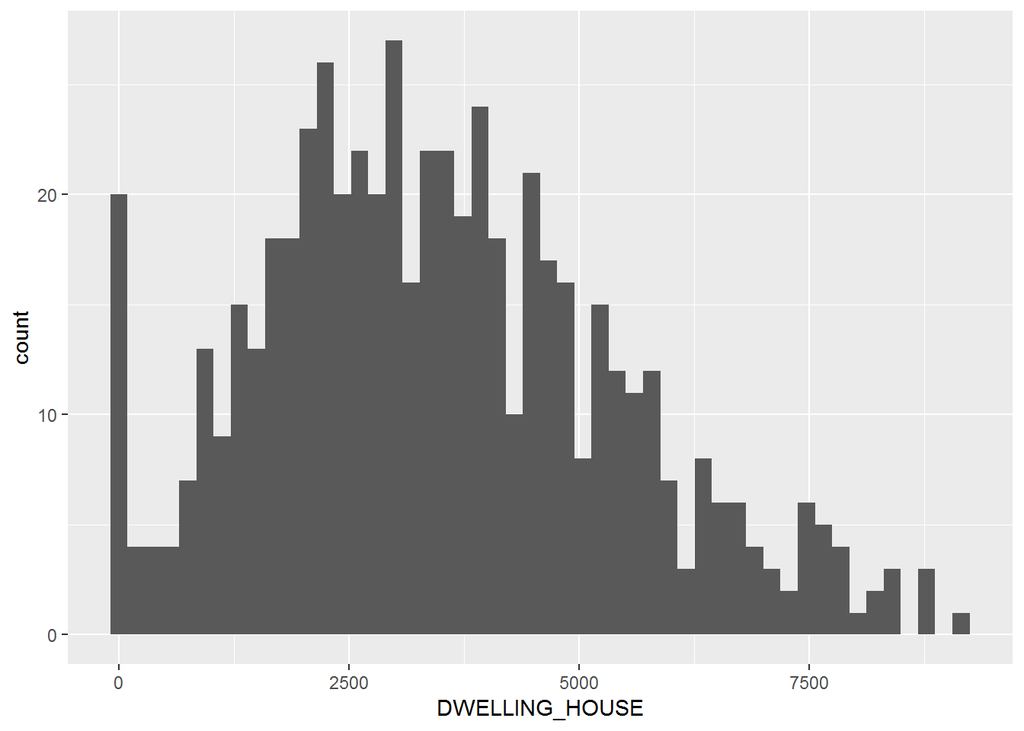

```r
## DWELLING HOUSE
# Some areas in NSW have no houses - data may be slightly skewed
dwelling_type_filtered %>%
  ggplot() +
  geom_histogram(aes(x = DWELLING_HOUSE), bins = 50)
```

In addition a QQ-plot is created using standardised values. The standardisation calculation is:
$$z = \frac{x - \mu}{\delta}$$
A QQ-plot shows how close a sample is to normal distribution. The QQ plot orders the $z$ scores from low to high and plots each value’s $z$ score on the y axis; the x axis is the corresponding quantile of a normal distribution. Plots that closely follow the line are normally distributed.

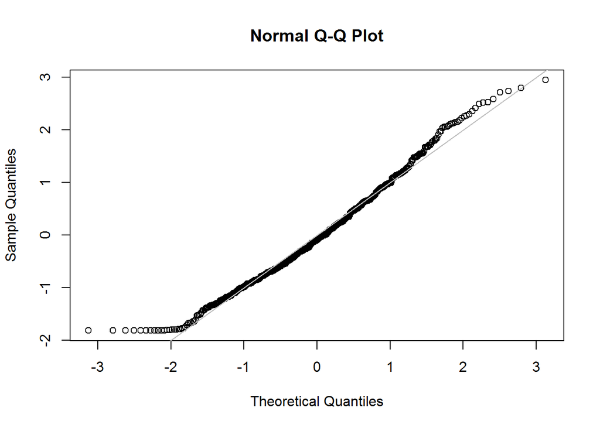

```r
# Standardise data and confirm data has a long tail
house_std <- scale(dwelling_type_filtered$DWELLING_HOUSE)
qqnorm(house_std)
abline(a = 0, b = 1, col = 'grey')
```

#### Dwelling - Flat

Normal distribution is checked for flats but first the SA2’s with no flats are checked and seem to be OK. The areas returned are industrial areas, offshore shipping and rural areas which probably don’t have flats.

As can be seen flat data is defintiely not normally distributed.

```r
## DWELLING FLAT
# There are 21 no flat SA2's in NSW - industrial areas, offshore shipping, Rural areas
dwelling_type_filtered %>%
  filter(DWELLING_FLAT == 0) %>%
  select(SA2_CODE, SA2_NAME_2016, PERC_DWELLING_HOUSE, PERC_DWELLING_FLAT, PERC_DWELLING_SEMI, PERC_DWELLING_OTHER)
```

```
## # A tibble: 21 x 6
##    SA2_CODE SA2_NAME_2016 PERC_DWELLING_H~ PERC_DWELLING_F~
##       <int> <chr>                    <dbl>            <dbl>
##  1   1.01e8 Deua - Wadbi~            0.842                0
##  2   1.05e8 Dubbo Region             0.977                0
##  3   1.07e8 Port Kembla ~            0                    0
##  4   1.08e8 Lord Howe Is~            0.907                0
##  5   1.11e8 Newcastle Po~            1                    0
##  6   1.12e8 Terranora - ~            0.997                0
##  7   1.14e8 Ettrema - Sa~            1                    0
##  8   1.14e8 Tomerong - W~            0.959                0
##  9   1.14e8 Robertson - ~            0.986                0
## 10   1.16e8 Prospect Res~            0.667                0
## # ... with 11 more rows, and 2 more variables: PERC_DWELLING_SEMI <dbl>,
## #   PERC_DWELLING_OTHER <dbl>
```

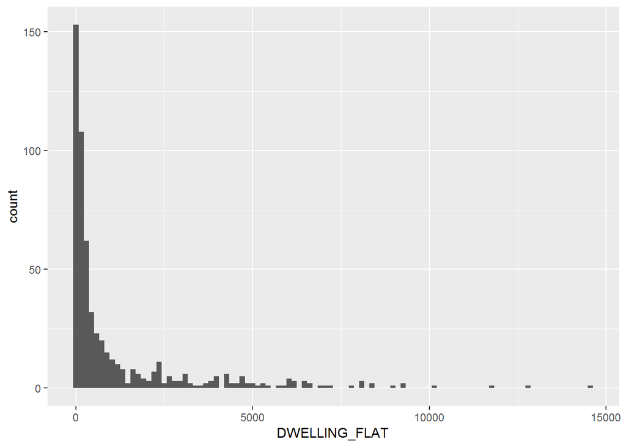

```r
# Some areas in NSW have no houses - data skewed
dwelling_type_filtered %>%
  ggplot() +
  geom_histogram(aes(x = DWELLING_FLAT), bins = 100)
```

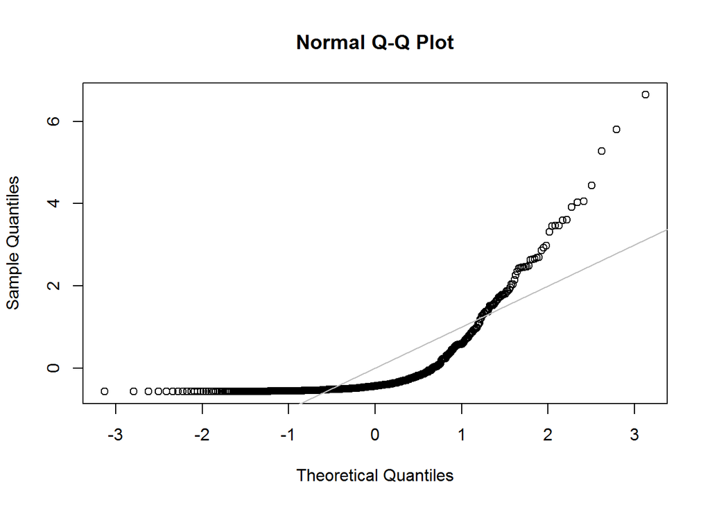

```r
# Standardise data and confirm data is not normally distributed
flat_std <- scale(dwelling_type_filtered$DWELLING_FLAT)
qqnorm(flat_std)
abline(a = 0, b = 1, col = 'grey')
```

#### Dwelling - Semi

```r
## DWELLING SEMI
# There are 19 no semi SA2's in NSW - industrial areas, airport, offshore shipping, rural areas
dwelling_type_filtered %>%
  filter(DWELLING_SEMI == 0) %>%
  select(SA2_CODE, SA2_NAME_2016, PERC_DWELLING_HOUSE, PERC_DWELLING_FLAT, PERC_DWELLING_SEMI, PERC_DWELLING_OTHER)
```

```
## # A tibble: 19 x 6
##    SA2_CODE SA2_NAME_2016 PERC_DWELLING_H~ PERC_DWELLING_F~
##       <int> <chr>                    <dbl>            <dbl>
##  1   1.01e8 Deua - Wadbi~            0.842          0
##  2   1.06e8 Singleton Re~            0.969          0.00632
##  3   1.07e8 Port Kembla ~            0              0
##  4   1.08e8 Lord Howe Is~            0.907          0
##  5   1.10e8 Gunnedah Reg~            0.939          0.0220
##  6   1.11e8 Newcastle Po~            1              0
##  7   1.12e8 Terranora - ~            0.997          0
##  8   1.14e8 Ettrema - Sa~            1              0
##  9   1.16e8 Prospect Res~            0.667          0
## 10   1.17e8 Port Botany ~            0              0
## 11   1.17e8 Sydney Airpo~            0              0
## 12   1.24e8 Blue Mountai~            1              0
## 13   1.24e8 Blue Mountai~            0.421          0
## 14   1.25e8 Smithfield I~            0              0
## 15   1.27e8 Badgerys Cre~            0.844          0
## 16   1.27e8 Horsley Park~            0.986          0.00376
## 17   1.27e8 Wetherill Pa~            0              0.5
## 18   1.28e8 Royal Nation~            0.267          0
## 19   1.98e8 Migratory - ~            0              0
## # ... with 2 more variables: PERC_DWELLING_SEMI <dbl>,
## #   PERC_DWELLING_OTHER <dbl>
```

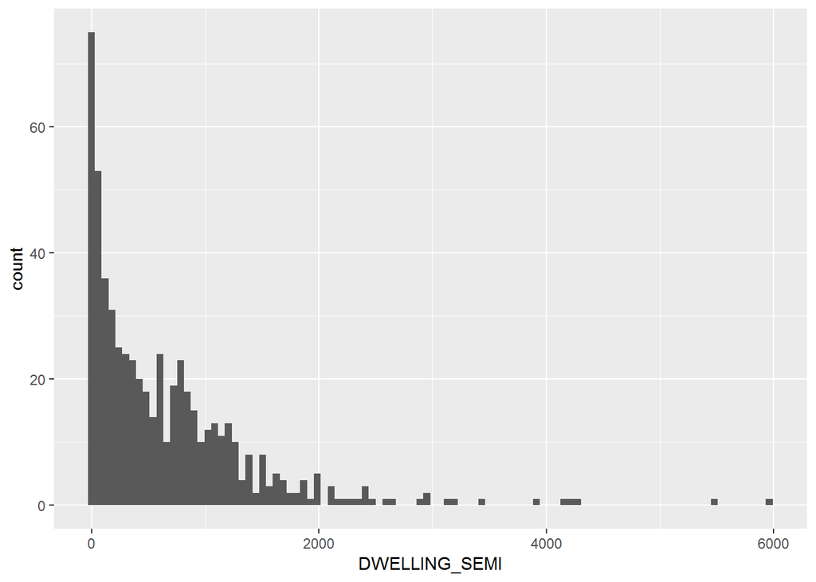

```r
# Some areas in NSW have no houses - data skewed
dwelling_type_filtered %>%
  ggplot() +
  geom_histogram(aes(x = DWELLING_SEMI), bins = 100)
```

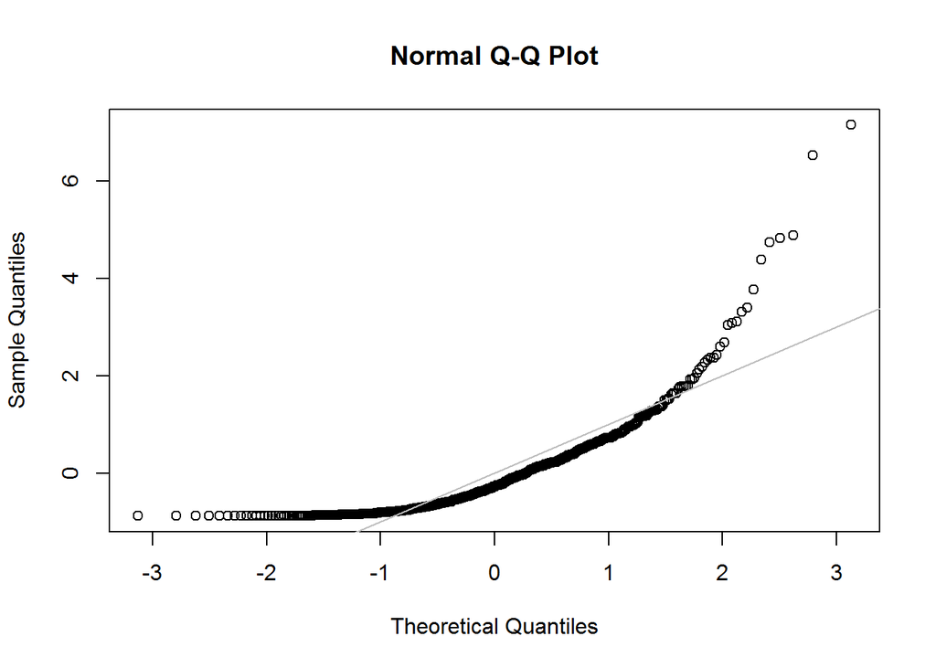

```r
# Standardise data and confirm data is not normally distributed
semi_std <- scale(dwelling_type_filtered$DWELLING_SEMI)
qqnorm(semi_std)
abline(a = 0, b = 1, col = 'grey')
```

### Correlations check

Using the Hmisc::rcorr function shows that there are some positive and negative correlations but nothing seriously high.

The corrplot::corrplot function shows this visually.

```r
# Check correlation between variables
dwelling_matrix <- dwelling_type_filtered %>%
  select(DWELLING_FLAT,DWELLING_HOUSE,DWELLING_OTHER,DWELLING_SEMI) %>%
  as.matrix()

# Show values - nothing really high
rcorr(dwelling_matrix, type = "pearson")
```

```
##                DWELLING_FLAT DWELLING_HOUSE DWELLING_OTHER DWELLING_SEMI
## DWELLING_FLAT           1.00          -0.26           0.05          0.39
## DWELLING_HOUSE         -0.26           1.00           0.18          0.12
## DWELLING_OTHER          0.05           0.18           1.00          0.10
## DWELLING_SEMI           0.39           0.12           0.10          1.00
##
## n= 570
##
##
## P
##                DWELLING_FLAT DWELLING_HOUSE DWELLING_OTHER DWELLING_SEMI
## DWELLING_FLAT                0.0000         0.2020         0.0000
## DWELLING_HOUSE 0.0000                       0.0000         0.0032
## DWELLING_OTHER 0.2020        0.0000                        0.0136
## DWELLING_SEMI  0.0000        0.0032         0.0136
```

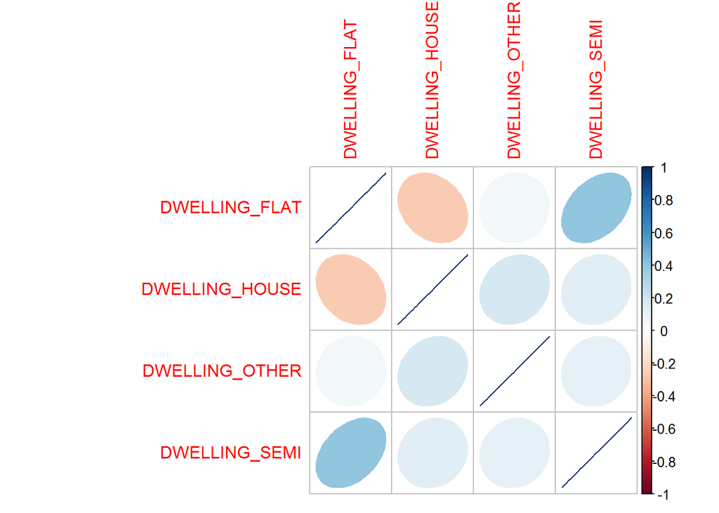

```r
# And a plot for good measure
corrplot(cor(dwelling_matrix), method = "ellipse")
```

### Questions

What do we want to do with SA2’s with no dwellings?